# Final Project: Analysis of Starbucks Drinks

Team Caffeine: Brynn VanHorn, Mackenzie Donaubauer, Samuel Husted

12/12/2023

[figure not shown]

## Introduction

**Our Dataset:** This dataset is from kaggle.com. It includes majority of the common drinks found at Starbucks and has all the nutritional values associated with that drink.

**Why:** It is useful for those who enjoy buying drinks to know what ingredients they contain so they get their money’s worth. We can use this information to estimate how many calories make up a drink based on other nutritional values.

## Project Objective

> How do nutritional factors contribute to calorie count? We are going to predict how many calories are in any fast food coffee drink based on the combination of other factors that make up the drink.

### Step 1: Data Loading and Inspection

First, we grab the dataset and analyze the data. We want to understand the structure and summary of our data set so we can properly clean or change it before further exploration.

We can already tell some column variable types need to change. Continue throught the report to see that below.

```r
library(tidyverse)
starbucks_data <- read.csv("starbucks.csv")

str(starbucks_data)
```

```
## 'data.frame':    242 obs. of  18 variables:
##  $ Beverage_category      : chr  "Coffee" "Coffee" "Coffee" "Coffee" ...
##  $ Beverage               : chr  "Brewed Coffee" "Brewed Coffee" "Brewed Coffee" "Brewed Coffee" ...
##  $ Beverage_prep          : chr  "Short" "Tall" "Grande" "Venti" ...
##  $ Calories               : int  3 4 5 5 70 100 70 100 150 110 ...
##  $ Total.Fat..g.          : chr  "0.1" "0.1" "0.1" "0.1" ...
##  $ Trans.Fat..g.          : num  0 0 0 0 0.1 2 0.4 0.2 3 0.5 ...
##  $ Saturated.Fat..g.      : num  0 0 0 0 0 0.1 0 0 0.2 0 ...
##  $ Sodium..mg.            : int  0 0 0 0 5 15 0 5 25 0 ...
##  $ Total.Carbohydrates..g.: int  5 10 10 10 75 85 65 120 135 105 ...
##  $ Cholesterol..mg.       : int  0 0 0 0 10 10 6 15 15 10 ...
##  $ Dietary.Fibre..g.      : int  0 0 0 0 0 0 1 0 0 1 ...
##  $ Sugars..g.             : int  0 0 0 0 9 9 4 14 14 6 ...
##  $ Protein..g.            : num  0.3 0.5 1 1 6 6 5 10 10 8 ...
##  $ Vitamin.A....DV.       : chr  "0%" "0%" "0%" "0%" ...
##  $ Vitamin.C....DV.       : chr  "0%" "0%" "0%" "0%" ...
##  $ Calcium....DV.         : chr  "0%" "0%" "0%" "2%" ...
##  $ Iron....DV.            : chr  "0%" "0%" "0%" "0%" ...
##  $ Caffeine..mg.          : chr  "175" "260" "330" "410" ...
```

```r
summary(starbucks_data)
```

```
##  Beverage_category    Beverage         Beverage_prep         Calories
##  Length:242         Length:242         Length:242         Min.   :  0.0
##  Class :character   Class :character   Class :character   1st Qu.:120.0
##  Mode  :character   Mode  :character   Mode  :character   Median :185.0
##                                                           Mean   :193.9
##                                                           3rd Qu.:260.0
##                                                           Max.   :510.0
##  Total.Fat..g.      Trans.Fat..g.   Saturated.Fat..g.  Sodium..mg.
##  Length:242         Min.   :0.000   Min.   :0.0000    Min.   : 0.000
##  Class :character   1st Qu.:0.100   1st Qu.:0.0000    1st Qu.: 0.000
##  Mode  :character   Median :0.500   Median :0.0000    Median : 5.000
##                     Mean   :1.307   Mean   :0.0376    Mean   : 6.364
##                     3rd Qu.:2.000   3rd Qu.:0.1000    3rd Qu.:10.000
##                     Max.   :9.000   Max.   :0.3000    Max.   :40.000
##  Total.Carbohydrates..g. Cholesterol..mg. Dietary.Fibre..g.   Sugars..g.
##  Min.   :  0.0           Min.   : 0.00    Min.   :0.0000    Min.   : 0.00
##  1st Qu.: 70.0           1st Qu.:21.00    1st Qu.:0.0000    1st Qu.:18.00
##  Median :125.0           Median :34.00    Median :0.0000    Median :32.00
##  Mean   :128.9           Mean   :35.99    Mean   :0.8058    Mean   :32.96
##  3rd Qu.:170.0           3rd Qu.:50.75    3rd Qu.:1.0000    3rd Qu.:43.75
##  Max.   :340.0           Max.   :90.00    Max.   :8.0000    Max.   :84.00
##   Protein..g.     Vitamin.A....DV.   Vitamin.C....DV.   Calcium....DV.
##  Min.   : 0.000   Length:242         Length:242         Length:242
##  1st Qu.: 3.000   Class :character   Class :character   Class :character
##  Median : 6.000   Mode  :character   Mode  :character   Mode  :character
##  Mean   : 6.979
##  3rd Qu.:10.000
##  Max.   :20.000
##  Iron....DV.        Caffeine..mg.
##  Length:242         Length:242
##  Class :character   Class :character
##  Mode  :character   Mode  :character
##
##
##
```

There are a lot of variables to look at here. We have all the standard variables you see in nutritional facts such as the Calories, Vitamins, Fats, Cholesterol etc., which are goo variables to use for our further analysis of Calories. There are also beverage names, category and prep, which can be good to categorize our data later on.

```r
head(starbucks_data)
```

```
##         Beverage_category      Beverage     Beverage_prep Calories
## 1                  Coffee Brewed Coffee             Short        3
## 2                  Coffee Brewed Coffee              Tall        4
## 3                  Coffee Brewed Coffee            Grande        5
## 4                  Coffee Brewed Coffee             Venti        5
## 5 Classic Espresso Drinks   Caffè Latte Short Nonfat Milk       70
## 6 Classic Espresso Drinks   Caffè Latte           2% Milk      100
##   Total.Fat..g. Trans.Fat..g. Saturated.Fat..g. Sodium..mg.
## 1           0.1           0.0               0.0           0
## 2           0.1           0.0               0.0           0
## 3           0.1           0.0               0.0           0
## 4           0.1           0.0               0.0           0
## 5           0.1           0.1               0.0           5
## 6           3.5           2.0               0.1          15
##   Total.Carbohydrates..g. Cholesterol..mg. Dietary.Fibre..g. Sugars..g.
```

[output cut: 20 more lines]

### Step 2: Data Cleaning and Transformation

We clean the data by changing the type of columns from characters to numbers. This will be useful for calculations between variables later on. All of the vitamins were in percentages, so we take those divided by 100 to get their decimal proportion.

```r
numeric_columns <- c("Total.Fat..g.", "Caffeine..mg.")
starbucks_data[numeric_columns] <- lapply(starbucks_data[numeric_columns], as.numeric)

percentage_columns <- c("Vitamin.A....DV.", "Vitamin.C....DV.", "Calcium....DV.", "Iron....DV.")

starbucks_data[percentage_columns] <- lapply(starbucks_data[percentage_columns], function(x) {
  as.numeric(sub("%", "", x))/100
})

str(starbucks_data)
```

```
## 'data.frame':    242 obs. of  18 variables:
##  $ Beverage_category      : chr  "Coffee" "Coffee" "Coffee" "Coffee" ...
##  $ Beverage               : chr  "Brewed Coffee" "Brewed Coffee" "Brewed Coffee" "Brewed Coffee" ...
##  $ Beverage_prep          : chr  "Short" "Tall" "Grande" "Venti" ...
##  $ Calories               : int  3 4 5 5 70 100 70 100 150 110 ...
##  $ Total.Fat..g.          : num  0.1 0.1 0.1 0.1 0.1 3.5 2.5 0.2 6 4.5 ...
##  $ Trans.Fat..g.          : num  0 0 0 0 0.1 2 0.4 0.2 3 0.5 ...
##  $ Saturated.Fat..g.      : num  0 0 0 0 0 0.1 0 0 0.2 0 ...
##  $ Sodium..mg.            : int  0 0 0 0 5 15 0 5 25 0 ...
##  $ Total.Carbohydrates..g.: int  5 10 10 10 75 85 65 120 135 105 ...
##  $ Cholesterol..mg.       : int  0 0 0 0 10 10 6 15 15 10 ...
##  $ Dietary.Fibre..g.      : int  0 0 0 0 0 0 1 0 0 1 ...
##  $ Sugars..g.             : int  0 0 0 0 9 9 4 14 14 6 ...
##  $ Protein..g.            : num  0.3 0.5 1 1 6 6 5 10 10 8 ...
##  $ Vitamin.A....DV.       : num  0 0 0 0 0.1 0.1 0.06 0.15 0.15 0.1 ...
##  $ Vitamin.C....DV.       : num  0 0 0 0 0 0 0 0 0 0 ...
##  $ Calcium....DV.         : num  0 0 0 0.02 0.2 0.2 0.2 0.3 0.3 0.3 ...
##  $ Iron....DV.            : num  0 0 0 0 0 0 0.08 0 0 0.15 ...
##  $ Caffeine..mg.          : num  175 260 330 410 75 75 75 75 75 75 ...
```

We do more cleaning of the data by getting rid of the periods at the end of and in between each column name and replacing them with one simple underscore. This just helps with easier codding so we don’t have to write out something like this: Total.Fat…g.

```r
starbucks_data <- starbucks_data %>%
  rename_all(~str_replace_all(., "[[:space:](.)]", "_"))

starbucks_data <- starbucks_data %>%
  rename_all(~str_replace_all(., "_+", "_"))

starbucks_data <- starbucks_data %>%
  rename_all(~str_replace(., "_$", ""))

# Drop rows with NA values
starbucks_data <- na.omit(starbucks_data)

print(colnames(starbucks_data))
```

```
##  [1] "Beverage_category"     "Beverage"              "Beverage_prep"
##  [4] "Calories"              "Total_Fat_g"           "Trans_Fat_g"
##  [7] "Saturated_Fat_g"       "Sodium_mg"             "Total_Carbohydrates_g"
## [10] "Cholesterol_mg"        "Dietary_Fibre_g"       "Sugars_g"
## [13] "Protein_g"             "Vitamin_A_DV"          "Vitamin_C_DV"
## [16] "Calcium_DV"            "Iron_DV"               "Caffeine_mg"
```

### Step 3: Data Exploration and Visualization

Here we make a histogram where x is the number of calories and y is the frequency of beverages with x number of calories. It is good to interpret the distribution of Calories because this is our variable of focus.

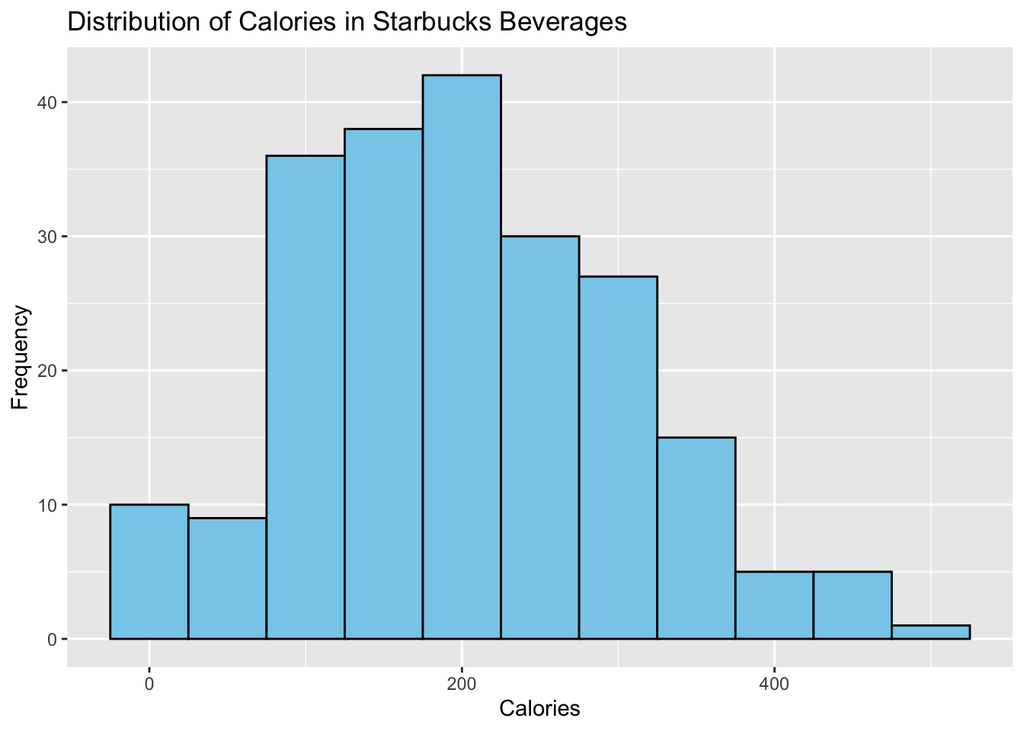

```r
ggplot(starbucks_data, aes(x = Calories)) +
  geom_histogram(binwidth = 50, fill = "skyblue", color = "black") +
  labs(title = "Distribution of Calories in Starbucks Beverages",
       x = "Calories", y = "Frequency")
```

**Calories Histogram:** As you can see, the Calories follow a normal distribution, where there is maybe a potential outlier at the end past the 500 calorie mark. And we learned earlier in our summary code that the mean is 193.9 and the median is 185 for amount of Calories in a coffee.

**Boxplots:** Next, we make a boxplot where we graphed the number of calories in relation to the category of beverage.

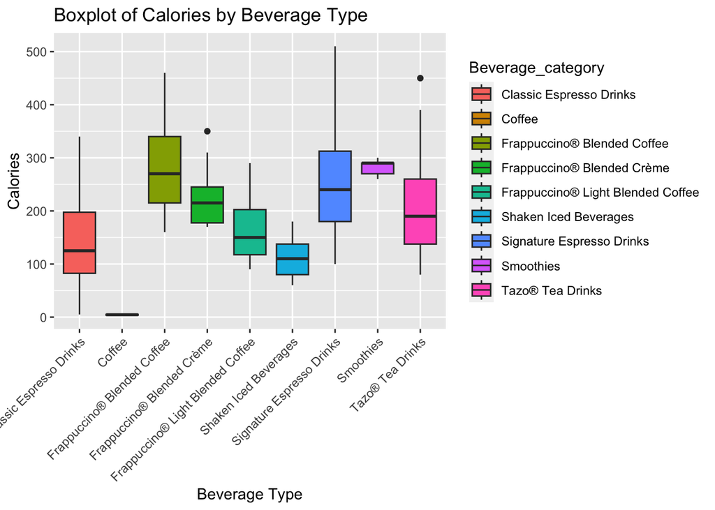

```r
boxplot_calories <- ggplot(starbucks_data, aes(x = Beverage_category, y = Calories, fill = Beverage_category)) +
  geom_boxplot() +
  labs(title = "Boxplot of Calories by Beverage Type",
       x = "Beverage Type", y = "Calories") +
  theme(axis.text.x = element_text(angle = 45, hjust = 1)) +
  scale_fill_discrete()

print(boxplot_calories)
```

## Step 4: Data Analysis and Prediction

Here we make a correlation matrix with columns we believe would be great candidates for determining number of calories. A correlation matrix provides a quick overview of the relationships between different variables in the dataset.Positive or negative correlation values indicate the direction and strength of the relationship between pairs of variables. Correlation analysis can be an initial step in generating hypotheses about potential relationships. It can guide further investigation and analysis. In this case, we hypothesize Sugars, Carbohydrates Cholesterol, and Total Fat have an effect on the amount of Calories in Starbucks beverages.

```r
selected_columns <- c("Sodium_mg", "Cholesterol_mg", "Dietary_Fibre_g", "Protein_g", "Calcium_DV", "Calories", "Total_Fat_g", "Sugars_g", "Total_Carbohydrates_g")
selected_data <- starbucks_data[selected_columns]

correlation_matrix <- cor(selected_data)
print(correlation_matrix)
```

```
##                         Sodium_mg Cholesterol_mg Dietary_Fibre_g Protein_g
## Sodium_mg              1.00000000      0.1859007     -0.07328018 0.4931971
## Cholesterol_mg         0.18590066      1.0000000      0.32696191 0.3206482
## Dietary_Fibre_g       -0.07328018      0.3269619      1.00000000 0.5131656
## Protein_g              0.49319713      0.3206482      0.51316563 1.0000000
## Calcium_DV             0.45057977      0.2213682      0.12475363 0.8407267
## Calories               0.37933797      0.9373648      0.36807083 0.5482321
## Total_Fat_g            0.58080113      0.3520884      0.25060614 0.5374929
## Sugars_g               0.19373222      0.9846379      0.17159452 0.2274472
## Total_Carbohydrates_g  0.26778491      0.7637489      0.13421084 0.3480085
##                       Calcium_DV  Calories Total_Fat_g  Sugars_g
## Sodium_mg              0.4505798 0.3793380   0.5808011 0.1937322
## Cholesterol_mg         0.2213682 0.9373648   0.3520884 0.9846379
## Dietary_Fibre_g        0.1247536 0.3680708   0.2506061 0.1715945
## Protein_g              0.8407267 0.5482321   0.5374929 0.2274472
## Calcium_DV             1.0000000 0.4850267   0.6034221 0.1962361
## Calories               0.4850267 1.0000000   0.6210144 0.9081315
## Total_Fat_g            0.6034221 0.6210144   1.0000000 0.3104969
## Sugars_g               0.1962361 0.9081315   0.3104969 1.0000000
## Total_Carbohydrates_g  0.3446691 0.7811054   0.4128118 0.7762142
##                       Total_Carbohydrates_g
## Sodium_mg                         0.2677849
## Cholesterol_mg                    0.7637489
## Dietary_Fibre_g                   0.1342108
## Protein_g                         0.3480085
## Calcium_DV                        0.3446691
## Calories                          0.7811054
## Total_Fat_g                       0.4128118
## Sugars_g                          0.7762142
## Total_Carbohydrates_g             1.0000000
```

Then we graphed scatterplots of the top 4 highest correlations with Calories. Why we coded our scatterplots the way we did:

- Scatter plots are effective for visualizing relationships between two continuous variables.
- Including a regression line helps identify trends and patterns in the data.
- Different colors for data points aid in distinguishing between the plots and highlight specific nutrient relationships.

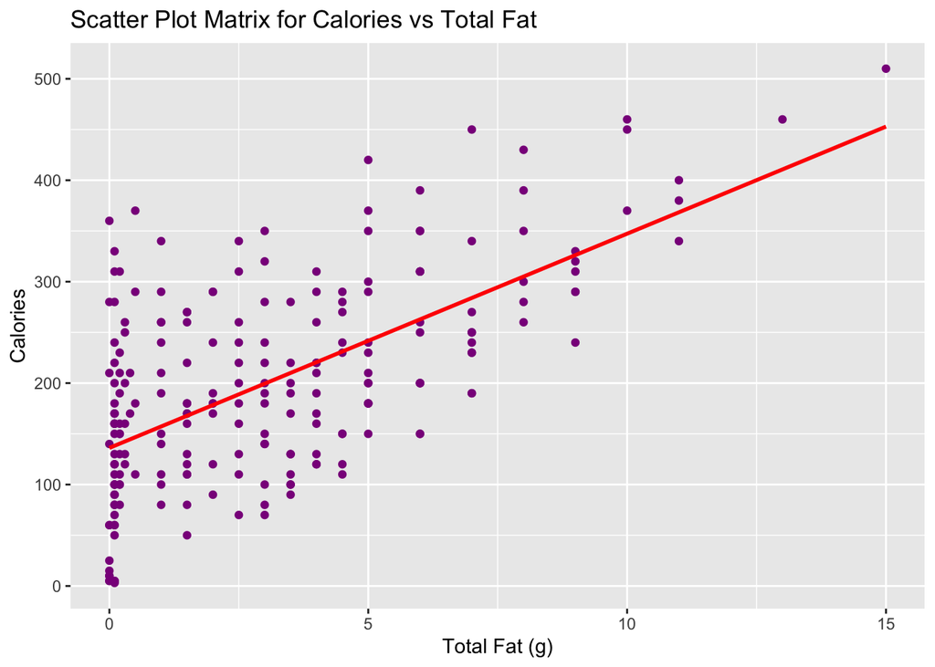

```r
scatterplot_totalfat <- ggplot(starbucks_data, aes(x = Total_Fat_g, y = Calories)) +
  geom_point(color = "darkmagenta") +
  geom_smooth(method = "lm", se = FALSE, color = "red") +
  labs(title = "Scatter Plot Matrix for Calories vs Total Fat",
       x = "Total Fat (g)", y = "Calories")
scatterplot_totalfat
```

As you can see, this scatterplot shows poor correlation. Points show that many drinks have little to no fat with a wide range of calories. Few points reach the line.

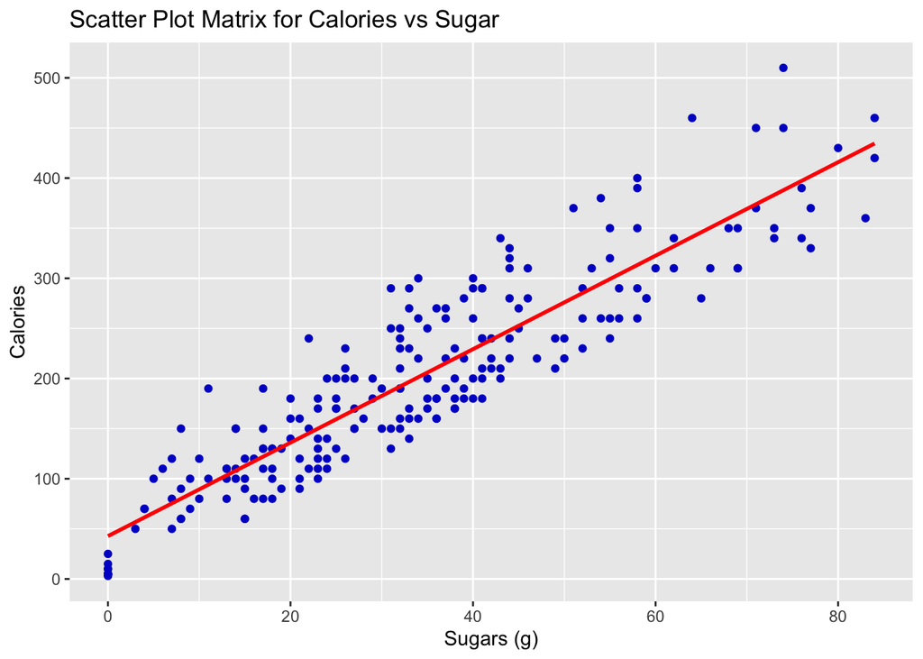

```r
scatterplot_sugar <- ggplot(starbucks_data, aes(x = Sugars_g, y = Calories)) +
  geom_point(color = "blue3") +
  geom_smooth(method = "lm", se = FALSE, color = "red") +
  labs(title = "Scatter Plot Matrix for Calories vs Sugar",
       x = "Sugars (g)", y = "Calories")
scatterplot_sugar
```

This regression fits well and many point fit the line. We hypothesized this would happen from the high correlation coefficient.

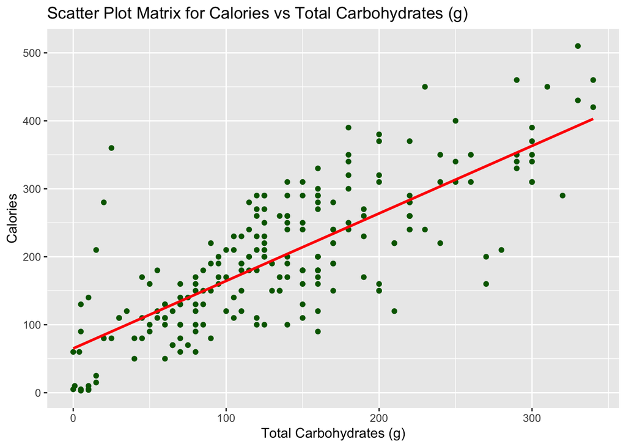

```r
scatterplot_carbs <- ggplot(starbucks_data, aes(x = Total_Carbohydrates_g, y = Calories)) +
  geom_point(color = "darkgreen") +
  geom_smooth(method = "lm", se = FALSE, color = "red") +
  labs(title = "Scatter Plot Matrix for Calories vs Total Carbohydrates (g)",
       x = "Total Carbohydrates (g)", y = "Calories")
scatterplot_carbs
```

This regression line fits okay within the points given of Carbs by Calories. There are definitely some potential outliers in this case.

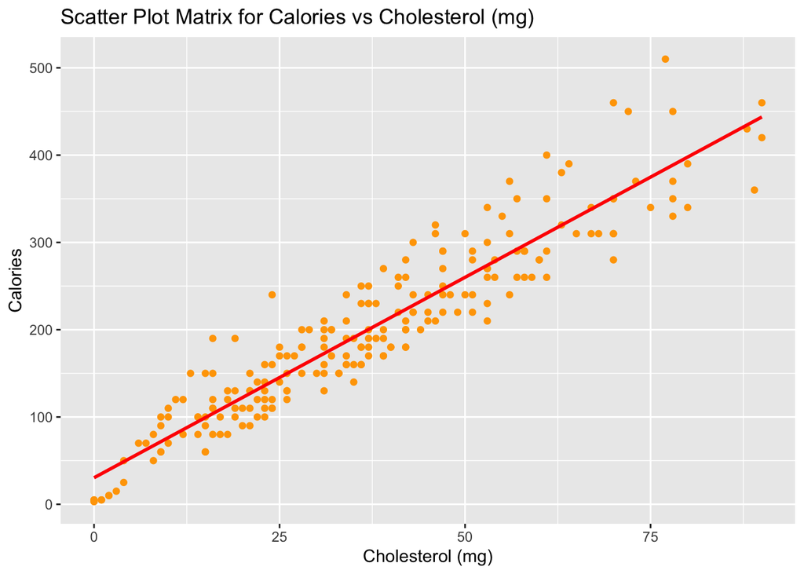

```r
scatterplot_cholesterol <- ggplot(starbucks_data, aes(x = Cholesterol_mg, y = Calories)) +
  geom_point(color = "orange") +
  geom_smooth(method = "lm", se = FALSE, color = "red") +
  labs(title = "Scatter Plot Matrix for Calories vs Cholesterol (mg)",
       x = "Cholesterol (mg)", y = "Calories")
scatterplot_cholesterol
```

This regression line fits really well with the points for Cholesterol and Calories.

**Prediction Model:**Lastly, we grabbed real data from a Dunkin’ Donuts Nutrition document and tested our accuracy of calculating the number of calories. Dunkin’ Donuts is a similar coffee chain and a common competitor for Starbucks. So drinks from their menu are a great comparison for predicting new drinks’ calories.

```r
#https://www.dunkindonuts.com/content/dam/dd/pdf/nutrition.pdf

carbs_linear_model <- lm(Calories ~ Total_Carbohydrates_g, data = starbucks_data)
sugar_linear_model <- lm(Calories ~ Sugars_g, data = starbucks_data)
fat_linear_model <- lm(Calories ~ Total_Fat_g, data = starbucks_data)
#chole_linear_model <- lm(Calories ~ Cholesterol_mg, data = starbucks_data)
multiple_linear_model <- lm(Calories ~ Total_Carbohydrates_g + Sugars_g + Total_Fat_g
                            #+ Cholesterol_mg
                            , data = starbucks_data)

new_data <- data.frame(
  Beverage = c("Original Hot Chocolate - Medium", "Hot Coffee - Large", "Hot Coffee with Sugar - Medium", "French Vanilla Swirl Frozen Coffee with Cream - Large"),
  Calories = c(330, 5, 110, 1110),
  Total_Carbohydrates_g = c(59, 0, 26, 180),
  Total_Fat_g = c(10, 0, 0, 40),
  Sugars_g = c(46, 0, 26, 169)
  #, Cholesterol_mg = c(0, 0, 0, 130)
  )

carb_predicted_calories <- predict(carbs_linear_model, newdata = new_data)
sugar_predicted_calories <- predict(sugar_linear_model, newdata = new_data)
fat_predicted_calories <- predict(fat_linear_model, newdata = new_data)
#chole_predicted_calories <- predict(chole_linear_model, newdata = new_data)
multi_predicted_calories <- predict(multiple_linear_model, newdata = new_data)

new_data_with_predictions <- cbind(new_data$Beverage, new_data$Calories,
                                   #chole_predicted_calories,
                                   carb_predicted_calories, sugar_predicted_calories, fat_predicted_calories, multi_predicted_calories)

colnames(new_data_with_predictions)[1] <- "Beverage"
colnames(new_data_with_predictions)[2] <- "Calories"

# Print the data frame with predicted calories
new_data_with_predictions
```

```
##   Beverage                                                Calories
## 1 "Original Hot Chocolate - Medium"                       "330"
## 2 "Hot Coffee - Large"                                    "5"
## 3 "Hot Coffee with Sugar - Medium"                        "110"
## 4 "French Vanilla Swirl Frozen Coffee with Cream - Large" "1110"
##   carb_predicted_calories sugar_predicted_calories fat_predicted_calories
## 1 "123.707727101133"      "257.288340125894"       "347.299189138733"
## 2 "65.1049925211983"      "42.7408031222943"       "136.117421803696"
## 3 "90.9299264038813"      "164.006802298242"       "136.117421803696"
## 4 "243.892996324388"      "830.969797765953"       "980.844491143843"
##   multi_predicted_calories
## 1 "332.385677922005"
## 2 "22.8845395572565"
## 3 "126.575792246606"
## 4 "1199.38967152042"
```

```r
#summary(carbs_linear_model)
```

Unfortunately, we took out cholesterol from this table as the accuracy was greatly reduced with Cholesterol in. If you want to check it out, uncomment all rows relating to obtaining cholesterol predicted values.

We assume that the decrease in accuracy when adding cholesterol might be due to a multicollinearity issue, where the model struggles to tease apart the individual impacts of highly correlated variables, leading to overfitting and reduced predictive performance. So we decided our model worked better without it.

### Conclusion

The results revealed that carbohydrates, sugar, and fat content could somewhat accurately predict calorie count in fast-food beverages. However, it was observed that the inclusion of cholesterol levels lowered the accuracy of these predictions. Expanding this investigation to encompass a wider array of food categories could offer deeper insights into how different nutritional components affect calorie estimation, despite the potential impact of cholesterol on predictive accuracy.

The inclusion of highly correlated variables, such as cholesterol, posed challenges to our machine learning models. This led to potential redundancy and diminished accuracy due to overfitting.It reminded us of the intricacies involved in analyzing real-world datasets. It highlighted the importance of thoughtful variable selection and handling correlated features. Data cleaning and transformation played a crucial role in preparing the dataset for analysis. We renamed and standardized column names, handled missing values, and transformed variables to make them suitable for analysis. Correlation analyses unveiled relationships between nutritional components, helping us understand how total fat, sugars, and carbohydrates contribute to the caloric content of Starbucks beverages.The Starbucks project serves as a foundation for continuous exploration and refinement. Future analyses could delve deeper into specific beverage categories, customer preferences, or regional variations.

In conclusion, the Starbucks project was not just about extracting nutritional insights but also navigating the nuances of data exploration, cleaning, and model interpretation. As we wrap up this phase of exploration, the project opens the door to further investigations and a deeper understanding of the intersection between consumer choices and nutritional content in the drinks we consume.